# Uebung_AlgoLAB_2_NN_Regression

Christoph Rabensteiner

19 Juni 2019

## Bitte um Beachtung der [uebungs-Policy](https://weblearn.fh-kufstein.ac.at/mod/page/view.php?id=46374) fuer genaue Anweisungen und einige Beurteilungsnotizen. Fehler bei der Einhaltung ergeben Punktabzug.

Bei dieser Uebung werden Sie:

-einen Datensatz partitionieren -Preprocessing anwenden -Regressionen mit dem neuronalen Netz durchführen -Regression mit OLS durchführen -Modelle vergleichen

Info: Maximale Anzahl erwerbare Punkte zur Benotung = 50

Wichtig! Um Algorithmusname und Parameter auszuwaehlen, bediene dich der jeweiligen Paketanleitung. Installiere benoetigte Pakete selbst. Bediene dich R Hilfe bezueglich Funktionen und dazugehoerigen Argumenten.

Der Datensatz beschreibt 13 numerische Eigenschaften von Häusern in Bostoner Vororten und befasst sich mit der Modellierung des Preises von Häusern in diesen Vororten in Tausenden von Dollar.

Y Variable (Responsevariable) ist “medv” (median value)

Importiere Daten:

```r
data = Boston
str(data)
```

```
## 'data.frame':    506 obs. of  14 variables:
##  $ crim   : num  0.00632 0.02731 0.02729 0.03237 0.06905 ...
##  $ zn     : num  18 0 0 0 0 0 12.5 12.5 12.5 12.5 ...
##  $ indus  : num  2.31 7.07 7.07 2.18 2.18 2.18 7.87 7.87 7.87 7.87 ...
##  $ chas   : int  0 0 0 0 0 0 0 0 0 0 ...
##  $ nox    : num  0.538 0.469 0.469 0.458 0.458 0.458 0.524 0.524 0.524 0.524 ...
##  $ rm     : num  6.58 6.42 7.18 7 7.15 ...
##  $ age    : num  65.2 78.9 61.1 45.8 54.2 58.7 66.6 96.1 100 85.9 ...
##  $ dis    : num  4.09 4.97 4.97 6.06 6.06 ...
##  $ rad    : int  1 2 2 3 3 3 5 5 5 5 ...
##  $ tax    : num  296 242 242 222 222 222 311 311 311 311 ...
##  $ ptratio: num  15.3 17.8 17.8 18.7 18.7 18.7 15.2 15.2 15.2 15.2 ...
##  $ black  : num  397 397 393 395 397 ...
##  $ lstat  : num  4.98 9.14 4.03 2.94 5.33 ...
##  $ medv   : num  24 21.6 34.7 33.4 36.2 28.7 22.9 27.1 16.5 18.9 ...
```

Normalisere Daten mit der minmax Methode (sog feature scaling) (2 Punkte)

**Normalisierung der Daten:**

```r
maxdata <- apply(data,2,max)
mindata = apply(data,2,min)
data_scaled <- as.data.frame(scale(data, center = mindata, scale=maxdata-mindata))
```

Partitioniere Daten in Training- und Testset mit einem Verhältnis von 70:30. Beachte die Reproduzierbarkeit. (2 Punkte)

**Train-Test Split:**

```r
set.seed(321)
index = sample(1:nrow(data), round(0.70*nrow(data)))
train_data <- as.data.frame(data_scaled[index,])
test_data <- as.data.frame(data_scaled[-index,1:13])
```

Stelle die Regressionsformel als String auf. Nutze dafür die Funktion paste und das Argument collapse (2 Punkte)

**Regressionsformel:**

```r
cnames <- colnames(train_data)
cnames2 <- cnames[-14]
formel <-  as.formula(paste("medv~", paste(cnames2, collapse = "+")))
```

Führe das Training des Modells mit 10 hidden Layers NN aus (Argument hidden). Benutze für das Training die Funktion neuralnet. Beachte das Argument linear.output. (4 Punkte)

**Neural Network Training:**

```r
NNModel = neuralnet(formel, data = train_data, hidden=10, linear.output = T)
```

Visualisiere Modell mit der Funktion plot (2 Punkte)

**Visualisierung:**

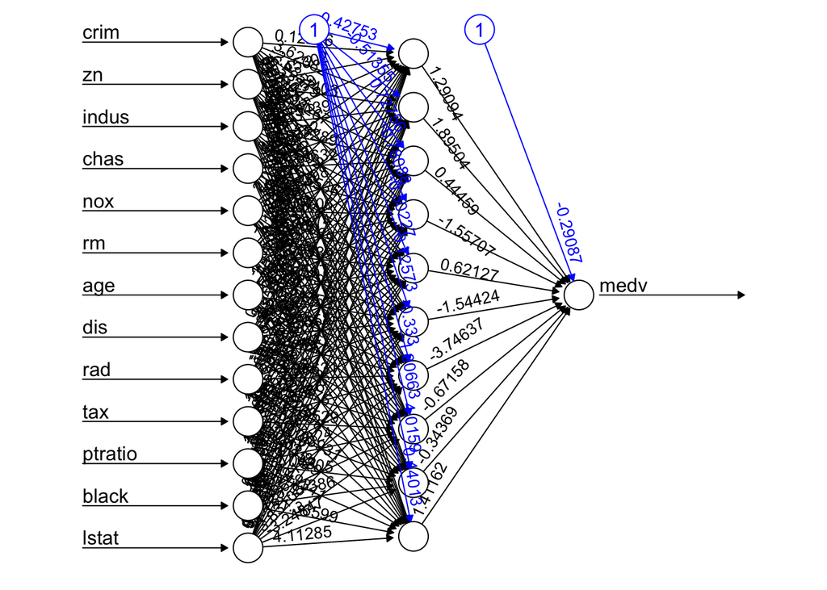

Prognostiziere Ergebnisse mit dem Testset mit der Funktion compute. Referenziere dabei das Paket mit der Funktion neuralnet::compute(… (3 Punkte)

**Vorhersage:**

```r
pred_nn1 <- neuralnet::compute(NNModel,test_data)
```

Berechne MSE Beachte, dass jetzt die prognostizierte Werte als auch Testwerte zuerst denormalisiert werden müssen. Dh die vorherige Normalisierung muss jetzt rückwerts berechnet werden. (3 Punkte)

**Unskalieren der Daten um Ergebnisse vergleichen zu können:**

```r
pred_unsc <- pred_nn1$net.result*(max(data$medv)-min(data$medv))+min(data$medv)
test_unsc <- as.data.frame(data[-index,])
```

**Berechnung MSE:**

```r
MSE_nn1 <- ModelMetrics::mse(test_unsc$medv, pred_unsc)
```

Generiere jetzt ein anderes Traingset und ein anderes Testset mit den vorhin generierten Indizes, aber diesmal mit originalen, nicht-normalisierten Daten. (2 Punkte)

**neues Trainingsset mit nicht-normalisierten Daten:**

```r
set.seed(321)
#index = sample(1:nrow(data), round(0.70*nrow(data)))
train_data2 <- as.data.frame(data[index,])
test_data2 <- as.data.frame(data[-index,])
```

Stelle ein OLS Rgeressionsmodell auf und führe Summary des Modells aus. (4 Punkte)

**OLS Regressionsmodell:**

```r
lmodel <- glm(medv~., data = train_data2)
summary(lmodel)
```

```
##
## Call:
## glm(formula = medv ~ ., data = train_data2)
##
## Deviance Residuals:
##      Min        1Q    Median        3Q       Max
## -16.9015   -2.4791   -0.6213    1.7091   25.4463
##
## Coefficients:
##               Estimate Std. Error t value Pr(>|t|)
## (Intercept)  24.244441   5.872945   4.128 4.61e-05 ***
## crim         -0.135053   0.038284  -3.528 0.000477 ***
## zn            0.046471   0.015324   3.033 0.002610 **
## indus         0.078652   0.073685   1.067 0.286544
## chas          1.927763   0.939714   2.051 0.040990 *
## nox         -13.493686   4.439844  -3.039 0.002556 **
## rm            4.550370   0.511677   8.893  < 2e-16 ***
## age           0.001206   0.015269   0.079 0.937082
## dis          -1.290457   0.236627  -5.454 9.52e-08 ***
## rad           0.251386   0.076693   3.278 0.001154 **
## tax          -0.011497   0.004458  -2.579 0.010340 *
## ptratio      -0.816689   0.147332  -5.543 5.97e-08 ***
## black         0.012964   0.002934   4.418 1.34e-05 ***
## lstat        -0.511667   0.063586  -8.047 1.44e-14 ***
## ---
## Signif. codes:  0 '***' 0.001 '**' 0.01 '*' 0.05 '.' 0.1 ' ' 1
##
## (Dispersion parameter for gaussian family taken to be 20.12269)
##
##     Null deviance: 29081.2  on 353  degrees of freedom
## Residual deviance:  6841.7  on 340  degrees of freedom
## AIC: 2083
##
## Number of Fisher Scoring iterations: 2
```

Prognostiziere Ergebnisse des OLS Modells mit dem Testset. (Funktion predict) (3 Punkte)

**Vorhersage:**

```r
pred_lm <- predict(lmodel, newdata=test_data2)
```

Berechne MSE für das OLS Modell (4 Punkte)

**Test-MSE**

```r
MSE_lm <- ModelMetrics::mse(test_data2$medv, pred_lm)
```

Vergleiche NN MSE und OLS MSE. (2 Punkte)

**Vergleich der ersten zwei Modelle:**

| Model | MSE |
| --- | --- |
| Test-MSE Neural Network: | 15.43658 |
| Test-MSE Linear Model: | 29.60822 |

Berechne jetzt ein Regressionsmodell mit neuronalem Netz mit 3 Hidden Layers und den normaliserten Daten. Das 1. Hidden Layer muss 5, das 2. muss 3 und das dritte 2 Neuronen haben. (6 Punkte)

**Datensatz mit normalisierten Daten:**

```r
train_data3 <- as.data.frame(data_scaled[index,])
test_data3 <- as.data.frame(data_scaled[-index,1:13])
```

**Model-Training:**

```r
#if linear.output = True -> Regessionsmodell wird berechnet.
NNModel2 = neuralnet(medv~., data = train_data3, hidden=c(5,3,2), linear.output = T)
```

Visualisiere Modell mit der Funktion plot (2 Punkte)

**Visualisierung:**

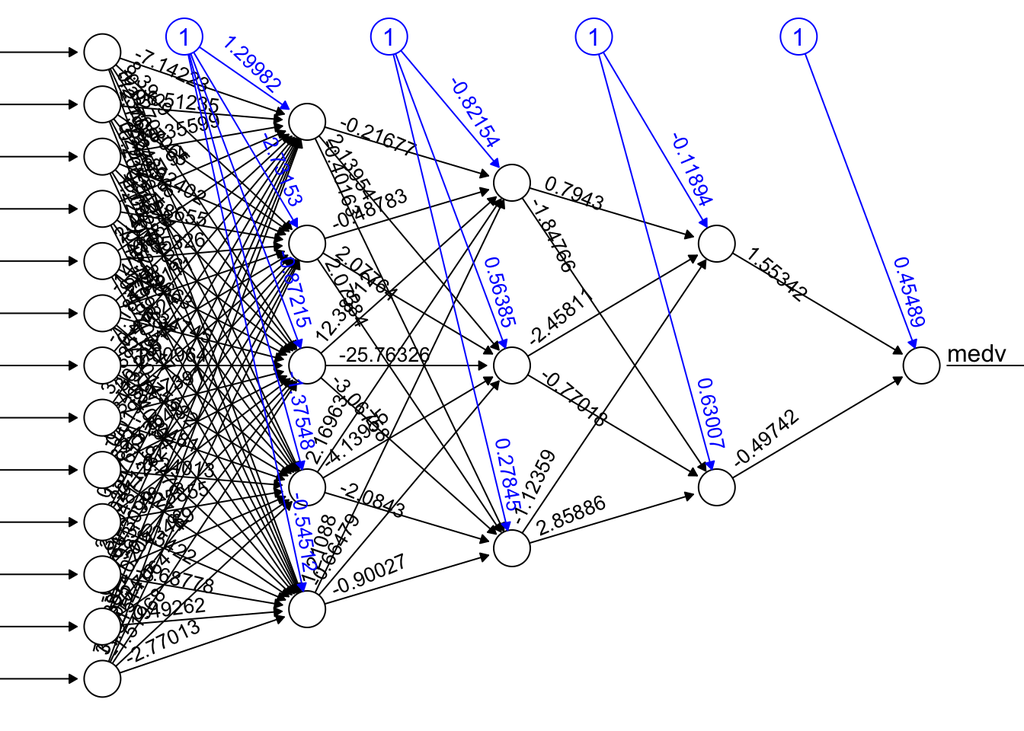

Prognostiziere Ergebnisse mit dem Testset (3 Punkte)

**Vorhersage:**

```r
pred_nn2 <- neuralnet::compute(NNModel2, test_data3)
```

**Unskalieren der Daten**

```r
pred_unsc3 <- pred_nn2$net.result*(max(data$medv)-min(data$medv))+min(data$medv)
test_unsc3 <- as.data.frame(data[-index,])
```

Berechne MSE (4 Punkte)

**Berechnung MSE:**

```r
MSE_nn2 <- ModelMetrics::mse(test_unsc3$medv, pred_unsc3)
```

Vergleiche jetzt den neuen NN MSE, den alten NN MSE und OLS MSE. (2 Punkte)

**Vergleich aller Modelle:**

| Model | MSE |
| --- | --- |
| Test-MSE Neural Network (1): | 15.43658 |
| Test-MSE Linear Model: | 29.60822 |
| Test-MSE Neural Network (2): | 12.02895 |